# Projecting the own affective states onto others: no influence of perceived similarity

Statistical analyses

Irene Trilla

22.12.2020

# Sample characteristics

```r
# descriptive statistics
table1::label(d.quest$gender) <- 'Gender'
table1::label(d.quest$age) <- 'Age'
table1::label(d.quest$education) <- 'Education'
table1::label(d.quest$occupation) <- 'Occupation'

table1::table1(~ gender + age + education + occupation,
                             data=d.quest, caption='Demographics')
```

Demographics

|  | Overall (N=64) |
| --- | --- |
| Gender |  |
| female | 31 (48.4%) |
| male | 32 (50.0%) |
| non-binary | 1 (1.6%) |
| Age |  |
| Mean (SD) | 27.0 (5.17) |
| Median [Min, Max] | 26.0 [19.0, 40.0] |
| Education |  |
| no_degree | 0 (0%) |
| elementary_school | 0 (0%) |
| lower_secondary_school | 0 (0%) |
| secondary_school | 6 (9.4%) |
| technical_college | 2 (3.1%) |
| high_school | 33 (51.6%) |
| university_degree | 23 (35.9%) |
| Occupation |  |
| retired | 0 (0%) |
| full_time | 8 (12.5%) |
| part_time | 6 (9.4%) |
| stay_at_home | 0 (0%) |
| student_uni | 41 (64.1%) |
| phd_student | 1 (1.6%) |
| intern | 2 (3.1%) |
| student_school | 0 (0%) |
| military_service | 0 (0%) |
| unemployed | 3 (4.7%) |
| other | 3 (4.7%) |

# Similarity manipulation

To manipulate the perceived similarity with the targets, participants were assigned one of two possible bogus cognitive styles (*Overestimator*, *Underestimator*), allegedly based on their performance on a dot estimation task. Next, participants learned the cognitive style of four different targets in an associative learning task.

The targets paired with the same cognitive style as the participant were considered the “Similar targets”, and those paired with the opposite cognitive style were the “Dissimilar targets”.

## Learning of cognitve styles

In the learning task, participants had to correctly categorize correctly each of the 4 targets, and themselves (“you” trials), into their cognitive styles in at least 8 of their last 10 trials completed. If participants did not reach this learning criterion by the 30th block of trials, the task stopped and the participant was considered as not having successfully learned the targets’ cognitive styles.

### Number of learning blocks

```r
# compute number of blocks and accuracy in the last 10 trials
d.learn %>%
  dplyr::group_by(id) %>%
  dplyr::filter(block>(max(block)-10)) %>%
  dplyr::summarise('N blocks'=max(block), 'Accuracy'=mean(accuracy)) %>%
  get_summary_stats('N blocks', 'Accuracy', type='common',
                    show=c('n', 'mean', 'sd', 'median', 'min', 'max')) %>%
  kbl(digits=2) %>%
  kable_styling(bootstrap_options=c('hover', 'condensed'), full_width=F, position='center')
```

| variable | n | mean | sd | median | min | max |
| --- | --- | --- | --- | --- | --- | --- |
| Accuracy | 64 | 0.93 | 0.04 | 0.94 | 0.76 | 1 |
| N blocks | 64 | 12.42 | 4.59 | 10.00 | 10.00 | 31 |

*Note that due to a coding error, two participants completed 31 blocks instead of the maximum of 30.

### Data exclusion

Data of 2 participants who did not achieve the learning criterion by the end of the learning task were excluded from the statistical analyses, as predefined in the [preregistration](https://osf.io/kjb84).

```r
d.learn.excl <- d.learn %>%

  # compute accuracy in the last 10 trials for each stimulus
  dplyr::group_by(id, similarity, identity) %>%
  dplyr::filter(block>(max(block)-10)) %>%
  dplyr::summarise(acc=mean(accuracy), n_blocks=max(block)) %>%

  # identify participants who did not learn all stimuli
  #   with at least 80% accuracy
  filter(acc<0.8 | n_blocks>29)

# mark participants to exclude for stats analyses
excl.id <- as.character(unique(d.learn.excl$id))
d.quest <- d.quest %>%
  mutate(exclude=id %in% excl.id) %>%
  mutate(exclude=factor(exclude, levels=c(TRUE, FALSE),
                        labels=c('Excluded ID', 'Analysis sample')))

# demographics of analysis sample
table1(~ gender + age | exclude, d.quest, overall='Original sample')
```

|  | Excluded ID (N=2) | Analysis sample (N=62) | Original sample (N=64) |
| --- | --- | --- | --- |
| Gender |  |  |  |
| female | 0 (0%) | 31 (50.0%) | 31 (48.4%) |
| male | 2 (100%) | 30 (48.4%) | 32 (50.0%) |
| non-binary | 0 (0%) | 1 (1.6%) | 1 (1.6%) |
| Age |  |  |  |
| Mean (SD) | 27.5 (9.19) | 26.9 (5.12) | 27.0 (5.17) |
| Median [Min, Max] | 27.5 [21.0, 34.0] | 26.0 [19.0, 40.0] | 26.0 [19.0, 40.0] |

## Face ratings

Before and after learning the cognitive styles, participants judged how similar they felt to each of the 4 targets (`rating_similarity`), how much they liked them (`rating_likeability`), and how sympathetic they found them (`rating_sympathy`). Ratings were performed on a 9-point scale.

```r
# descriptive statistics
table1(~ rating_similarity + rating_likeability + rating_sympathy | time + similarity, d.ratings,
       overall=FALSE, render.continuous=my.render.cont,
       caption=' Mean (SD) of face ratings')
```

Mean (SD) of face ratings

|  | pre similar (N=62) | pre dissimilar (N=62) | post similar (N=62) | post dissimilar (N=62) |
| --- | --- | --- | --- | --- |
| rating_similarity | 4.11 (1.49) | 4.13 (1.51) | 5.19 (1.81) | 3.96 (1.38) |
| rating_likeability | 4.98 (1.45) | 5.16 (1.44) | 5.55 (1.66) | 4.72 (1.40) |
| rating_sympathy | 4.85 (1.33) | 5.02 (1.33) | 5.48 (1.57) | 4.83 (1.39) |

### Similarity

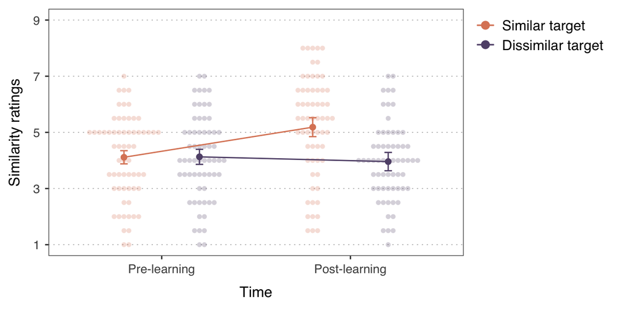

```r
# means & confidence intervals (within-subject, method from Morey 2008)
descr.similarity <- summarySEwithin(data=d.ratings, measurevar='rating_similarity',
                                    betweenvars=NULL, withinvars=c('time', 'similarity'),
                                    idvar='id', na.rm=FALSE, conf.interval=0.95)

# figure
ggplot(descr.similarity, aes(y=rating_similarity, x=time, color=similarity, fill=similarity)) +

  # plot individual observations
  geom_dotplot(data=d.ratings, aes(y=rating_similarity, x=time, fill=similarity), method='histodot',
               binwidth=0.5, dotsize=0.35, binaxis='y', stackdir='centerwhole',
                alpha=.25, stroke=0, position=position_dodge(dodge_width)) +

  # plot means and CI
  geom_point(position=position_dodge(dodge_width), size=point_size-0.08) +
  geom_line(aes(group=similarity), position=position_dodge(dodge_width)) +
  geom_errorbar(aes(ymin=rating_similarity-ci, ymax=rating_similarity+ci), width=error_width, size=0.5, position=position_dodge(dodge_width)) +

  # format
  scale_y_continuous(name='Similarity ratings', breaks=seq(1, 9, by=2), limits=c(1,9)) +
  scale_x_discrete(name='Time', labels=labels_time) +
  scale_color_manual(values=color_similarity, labels=labels_similarity) +
  scale_fill_manual(values=color_similarity, labels=labels_similarity) +
  guides(color=guide_legend(override.aes=list(alpha=1))) +
  my_theme
```

To check whether participants perceived as more similar the targets with whom they shared the same cognitive style, compared to those paired with the opposite cognitive style, a repeated-measures ANOVA was conducted with `Similarity` (similar target, dissimilar target) and `Time` (pre-learning, post-learning) as within-subject factors.

```r
# anova
m.similarity <- aov_4(rating_similarity ~ time*similarity + (time*similarity|id), d.ratings)
kbl(nice(m.similarity, es='pes'), caption='ANOVA (Similarity ratings)') %>%
  kable_styling(bootstrap_options=c('hover', 'condensed'), full_width=F, position='center')
```

ANOVA (Similarity ratings)

| Effect | df | MSE | F | pes | p.value |
| --- | --- | --- | --- | --- | --- |
| time | 1, 61 | 0.80 | 15.75 *** | .205 | <.001 |
| similarity | 1, 61 | 1.70 | 13.34 *** | .179 | <.001 |
| time:similarity | 1, 61 | 1.53 | 15.60 *** | .204 | <.001 |

Post-hoc tests were applied to follow up the significant `Similarity * Time`. P-values are adjusted for multiple testing using the Holm-Bonferroni method.

```r
# pairwise comparisons by Time
# ~~~~~~~~~~~~~~~~~~~~~~~~~~~~
ph.similarity.bytime <- d.ratings %>%
  group_by(time) %>%
  pairwise_t_test(rating_similarity~similarity, paired=TRUE, detailed=TRUE)

# add effect size
ph.similarity.bytime <-d.ratings %>%
  group_by(time) %>%
  cohens_d(rating_similarity~similarity, paired=TRUE) %>%
  inner_join(ph.similarity.bytime) %>%
  select('Level'=time, 'Condition 1'=group1, 'Condition 2'=group2, 'N'=n1,
         'Estimate'=estimate, 't'=statistic, 'DF'=df, 'p'=p,
         'CI Low'=conf.low, 'CI High'=conf.high, "Cohen's d"=effsize)

# pairwise comparisons by Similarity
# ~~~~~~~~~~~~~~~~~~~~~~~~~~~~~~~~~~
# t-tests
ph.similarity.bytarget <- d.ratings %>%
  dplyr::group_by(similarity) %>%
  pairwise_t_test(rating_similarity~time, paired=TRUE, detailed=TRUE)

# add effect size
ph.similarity.bytarget <-d.ratings %>%
  dplyr::group_by(similarity) %>%
  cohens_d(rating_similarity~time, paired=TRUE) %>%
  inner_join(ph.similarity.bytarget) %>%
  select('Level'=similarity, 'Condition 1'=group1, 'Condition 2'=group2, 'N'=n1,
         'Estimate'=estimate, 't'=statistic, 'DF'=df, 'p'=p,
         'CI Low'=conf.low, 'CI High'=conf.high, "Cohen's d"=effsize)

# merge both groups of comparisons and correct p-value for multiple comparisons
ph.similarity <- rbind(ph.similarity.bytime, ph.similarity.bytarget)
ph.similarity$p <- p.adjust(ph.similarity$p, method='holm')
kbl(ph.similarity, digits=2, caption='Pairwise comparisons (Similarity ratings)') %>%
  kable_styling(bootstrap_options=c('hover', 'condensed'), full_width=F, position='center')
```

Pairwise comparisons (Similarity ratings)

| Level | Condition 1 | Condition 2 | N | Estimate | t | DF | p | CI Low | CI High | Cohen’s d |
| --- | --- | --- | --- | --- | --- | --- | --- | --- | --- | --- |
| pre | similar | dissimilar | 62 | -0.02 | -0.09 | 61 | 0.93 | -0.39 | 0.36 | -0.01 |
| post | similar | dissimilar | 62 | 1.23 | 4.65 | 61 | 0.00 | 0.70 | 1.75 | 0.59 |
| similar | pre | post | 62 | -1.07 | -5.67 | 61 | 0.00 | -1.45 | -0.69 | -0.72 |
| dissimilar | pre | post | 62 | 0.17 | 0.85 | 61 | 0.80 | -0.23 | 0.57 | 0.11 |

### Likeability

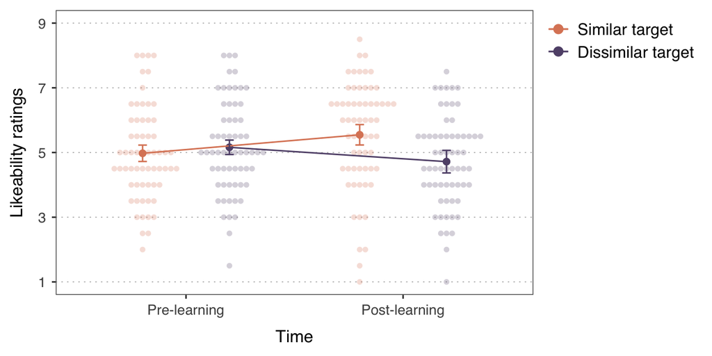

```r
# means & confidence intervals (within-subject, method from Morey 2008)
descr.likeability <- summarySEwithin(data=d.ratings, measurevar='rating_likeability',
                                    betweenvars=NULL, withinvars=c('time', 'similarity'),
                                    idvar='id', na.rm=FALSE, conf.interval=0.95)

# figure
ggplot(descr.likeability, aes(y=rating_likeability, x=time, color=similarity, fill=similarity)) +

  # plot individual observations
  geom_dotplot(data=d.ratings, aes(y=rating_likeability, x=time, fill=similarity), method='histodot',
               binwidth=0.5, dotsize=0.35, binaxis='y', stackdir='centerwhole',
                alpha=.25, stroke=0, position=position_dodge(dodge_width)) +

  # plot means and CI
  geom_point(position=position_dodge(dodge_width), size=point_size-0.08) +
  geom_line(aes(group=similarity), position=position_dodge(dodge_width)) +
  geom_errorbar(aes(ymin=rating_likeability-ci, ymax=rating_likeability+ci), width=error_width, size=0.5, position=position_dodge(dodge_width)) +

  # format
  scale_y_continuous(name='Likeability ratings', breaks=seq(1, 9, by=2), limits=c(1,9)) +
  scale_x_discrete(name='Time', labels=labels_time) +
  scale_color_manual(values=color_similarity, labels=labels_similarity) +
  scale_fill_manual(values=color_similarity, labels=labels_similarity) +
  guides(color=guide_legend(override.aes=list(alpha=1))) +
  my_theme
```

To check whether participants liked more the targets associated with the same cognitive style as themselves, compared to those paired with the opposite cognitive style, a repeated-measures ANOVA was conducted with `Similarity` (similar target, dissimilar target) and `Time` (pre-learning, post-learning) as within-subject factors.

```r
# anova
m.likeability <- aov_4(rating_likeability ~ time*similarity + (time*similarity|id), d.ratings)
kbl(nice(m.likeability, es='pes'), caption='ANOVA (Likeability ratings)') %>%
  kable_styling(bootstrap_options=c('hover', 'condensed'), full_width=F, position='center')
```

ANOVA (Likeability ratings)

| Effect | df | MSE | F | pes | p.value |
| --- | --- | --- | --- | --- | --- |
| time | 1, 61 | 0.54 | 0.48 | .008 | .492 |
| similarity | 1, 61 | 2.42 | 2.67 | .042 | .107 |
| time:similarity | 1, 61 | 0.94 | 16.94 *** | .217 | <.001 |

Post-hoc tests were applied to follow-up the significant `Similarity * Time`. P-values are adjusted for multiple testing using the Holm-Bonferroni method.

```r
# pairwise comparisons by Time
# ~~~~~~~~~~~~~~~~~~~~~~~~~~~~
ph.likeability.bytime <- d.ratings %>%
  group_by(time) %>%
  pairwise_t_test(rating_likeability~similarity, paired=TRUE, detailed=TRUE)

# add effect size
ph.likeability.bytime <-d.ratings %>%
  group_by(time) %>%
  cohens_d(rating_likeability~similarity, paired=TRUE) %>%
  inner_join(ph.likeability.bytime) %>%
  select('Level'=time, 'Condition 1'=group1, 'Condition 2'=group2, 'N'=n1,
         'Estimate'=estimate, 't'=statistic, 'DF'=df, 'p'=p,
         'CI Low'=conf.low, 'CI High'=conf.high, "Cohen's d"=effsize)

# pairwise comparisons by Similarity
# ~~~~~~~~~~~~~~~~~~~~~~~~~~~~~~~~~~
# t-tests
ph.likeability.bytarget <- d.ratings %>%
  dplyr::group_by(similarity) %>%
  pairwise_t_test(rating_likeability~time, paired=TRUE, detailed=TRUE)

# add effect size
ph.likeability.bytarget <-d.ratings %>%
  dplyr::group_by(similarity) %>%
  cohens_d(rating_likeability~time, paired=TRUE) %>%
  inner_join(ph.likeability.bytarget) %>%
  select('Level'=similarity, 'Condition 1'=group1, 'Condition 2'=group2, 'N'=n1,
         'Estimate'=estimate, 't'=statistic, 'DF'=df, 'p'=p,
         'CI Low'=conf.low, 'CI High'=conf.high, "Cohen's d"=effsize)

# merge both groups of comparisons and correct p-value for multiple comparisons
ph.likeability <- rbind(ph.likeability.bytime, ph.likeability.bytarget)
ph.likeability$p <- p.adjust(ph.likeability$p, method='holm')
kbl(ph.likeability, digits=2, caption='Pairwise comparisons (Likeability ratings)') %>%
  kable_styling(bootstrap_options=c('hover', 'condensed'), full_width=F, position='center')
```

Pairwise comparisons (Likeability ratings)

| Level | Condition 1 | Condition 2 | N | Estimate | t | DF | p | CI Low | CI High | Cohen’s d |
| --- | --- | --- | --- | --- | --- | --- | --- | --- | --- | --- |
| pre | similar | dissimilar | 62 | -0.19 | -1.00 | 61 | 0.32 | -0.55 | 0.18 | -0.13 |
| post | similar | dissimilar | 62 | 0.83 | 3.05 | 61 | 0.01 | 0.29 | 1.38 | 0.39 |
| similar | pre | post | 62 | -0.57 | -3.82 | 61 | 0.00 | -0.87 | -0.27 | -0.49 |
| dissimilar | pre | post | 62 | 0.44 | 2.78 | 61 | 0.01 | 0.12 | 0.76 | 0.35 |

### Sympathy

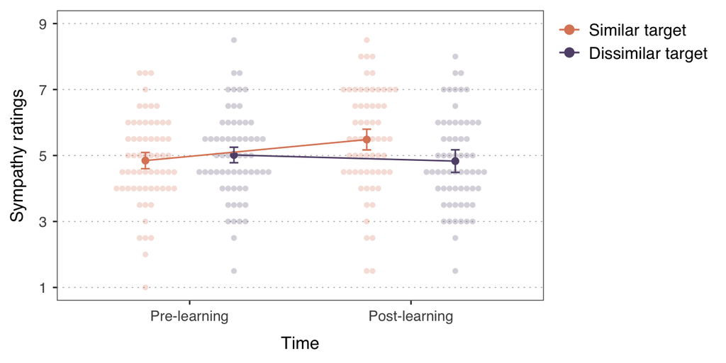

```r
# means & confidence intervals (within-subject, method from Morey 2008)
descr.sympathy <- summarySEwithin(data=d.ratings, measurevar='rating_sympathy',
                                    betweenvars=NULL, withinvars=c('time', 'similarity'),
                                    idvar='id', na.rm=FALSE, conf.interval=0.95)

# figure
ggplot(descr.sympathy, aes(y=rating_sympathy, x=time, color=similarity, fill=similarity)) +

  # plot individual observations
  geom_dotplot(data=d.ratings, aes(y=rating_sympathy, x=time, fill=similarity), method='histodot',
               binwidth=0.5, dotsize=0.35, binaxis='y', stackdir='centerwhole',
                alpha=.25, stroke=0, position=position_dodge(dodge_width)) +

  # plot means and CI
  geom_point(position=position_dodge(dodge_width), size=point_size-0.08) +
  geom_line(aes(group=similarity), position=position_dodge(dodge_width)) +
  geom_errorbar(aes(ymin=rating_sympathy-ci, ymax=rating_sympathy+ci), width=error_width, size=0.5, position=position_dodge(dodge_width)) +

  # format
  scale_y_continuous(name='Sympathy ratings', breaks=seq(1, 9, by=2), limits=c(1,9)) +
  scale_x_discrete(name='Time', labels=labels_time) +
  scale_color_manual(values=color_similarity, labels=labels_similarity) +
  scale_fill_manual(values=color_similarity, labels=labels_similarity) +
  guides(color=guide_legend(override.aes=list(alpha=1))) +
  my_theme
```

To check whether participants perceived as more sympathetic the targets associated with the same cognitive style as themselves, compared to those paired with the opposite cognitive style, a repeated-measures ANOVA was conducted with `Similarity` (similar target, dissimilar target) and `Time` (pre-learning, post-learning) as within-subject factors.

```r
# anova
m.sympathy <- aov_4(rating_sympathy ~ time*similarity + (time*similarity|id), d.ratings)
kbl(nice(m.sympathy, es='pes'), caption='ANOVA (Sympathy ratings)') %>%
  kable_styling(bootstrap_options=c('hover', 'condensed'), full_width=F, position='center')
```

ANOVA (Sympathy ratings)

| Effect | df | MSE | F | pes | p.value |
| --- | --- | --- | --- | --- | --- |
| time | 1, 61 | 0.67 | 4.72 * | .072 | .034 |
| similarity | 1, 61 | 2.22 | 1.64 | .026 | .206 |
| time:similarity | 1, 61 | 0.97 | 10.80 ** | .150 | .002 |

Post-hoc tests were applied to follow-up the significant `Similarity * Time`. P-values are adjusted for multiple testing using the Holm-Bonferroni method.

```r
# pairwise comparisons by Time
# ~~~~~~~~~~~~~~~~~~~~~~~~~~~~
ph.sympathy.bytime <- d.ratings %>%
  group_by(time) %>%
  pairwise_t_test(rating_sympathy~similarity, paired=TRUE, detailed=TRUE)

# add effect size
ph.sympathy.bytime <-d.ratings %>%
  group_by(time) %>%
  cohens_d(rating_sympathy~similarity, paired=TRUE) %>%
  inner_join(ph.sympathy.bytime) %>%
  select('Level'=time, 'Condition 1'=group1, 'Condition 2'=group2, 'N'=n1,
         'Estimate'=estimate, 't'=statistic, 'DF'=df, 'p'=p,
         'CI Low'=conf.low, 'CI High'=conf.high, "Cohen's d"=effsize)

# pairwise comparisons by Similarity
# ~~~~~~~~~~~~~~~~~~~~~~~~~~~~~~~~~~
# t-tests
ph.sympathy.bytarget <- d.ratings %>%
  dplyr::group_by(similarity) %>%
  pairwise_t_test(rating_sympathy~time, paired=TRUE, detailed=TRUE)

# add effect size
ph.sympathy.bytarget <-d.ratings %>%
  dplyr::group_by(similarity) %>%
  cohens_d(rating_sympathy~time, paired=TRUE) %>%
  inner_join(ph.sympathy.bytarget) %>%
  select('Level'=similarity, 'Condition 1'=group1, 'Condition 2'=group2, 'N'=n1,
         'Estimate'=estimate, 't'=statistic, 'DF'=df, 'p'=p,
         'CI Low'=conf.low, 'CI High'=conf.high, "Cohen's d"=effsize)

# merge both groups of comparisons and correct p-value for multiple comparisons
ph.sympathy <- rbind(ph.sympathy.bytime, ph.sympathy.bytarget)
ph.sympathy$p <- p.adjust(ph.sympathy$p, method='holm')
kbl(ph.sympathy, digits=2, caption='Pairwise comparisons (Sympathy ratings)') %>%
  kable_styling(bootstrap_options=c('hover', 'condensed'), full_width=F, position='center')
```

Pairwise comparisons (Sympathy ratings)

| Level | Condition 1 | Condition 2 | N | Estimate | t | DF | p | CI Low | CI High | Cohen’s d |
| --- | --- | --- | --- | --- | --- | --- | --- | --- | --- | --- |
| pre | similar | dissimilar | 62 | -0.17 | -0.94 | 61 | 0.56 | -0.53 | 0.19 | -0.12 |
| post | similar | dissimilar | 62 | 0.65 | 2.46 | 61 | 0.05 | 0.12 | 1.18 | 0.31 |
| similar | pre | post | 62 | -0.64 | -4.12 | 61 | 0.00 | -0.95 | -0.33 | -0.52 |
| dissimilar | pre | post | 62 | 0.19 | 1.09 | 61 | 0.56 | -0.15 | 0.53 | 0.14 |

# Affective self-projection

## Affective state manipulation

At the beginning of each block of the affective self-projection paradigm, participants watched a happy or a sad video aimed to induce positive or negative affective states. To assess the success of this manipulation, participants were asked to rate their mood on a 11-point scale (1 = negative affect; 11 = positive affect) right after they watched each video (i.e. before the emotion judgment task). Participants also reported their current mood at the end of each block (i.e. after emotion judgment task) to check whether the induced state was maintained throughout the emotion judgment trials.

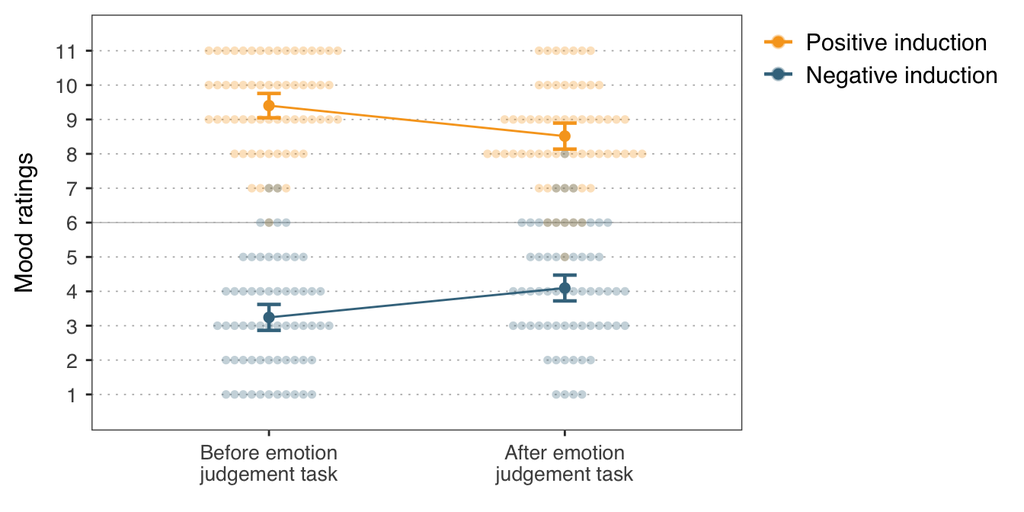

```r
# means & confidence intervals (within-subject, method from Morey 2008)
descr.mood <- summarySEwithin(data=d.mood, measurevar='mood',
                                    betweenvars=NULL, withinvars=c('affect', 'time'),
                                    idvar='id', na.rm=FALSE, conf.interval=0.95)

# figure
ggplot(descr.mood, aes(y=mood, x=time, color=affect)) +

  # horizontal line
  geom_hline(yintercept=6, color='grey', size=line_size*0.25) +

  # plot individual observations
  geom_dotplot(data=d.mood, aes(y=mood, x=time, fill=affect),
               binaxis='y', stackdir='centerwhole', alpha=.3, stroke=0, binwidth=0.25) +

  # plot means and CI
  geom_point(size=point_size) +
  geom_line(aes(group=affect)) +
  geom_errorbar(aes(ymin=mood-ci, ymax=mood+ci), width=error_width, size=error_size) +

  # format
  scale_y_continuous(name='Mood ratings', breaks=seq(1, 11, by=1), limits=c(0.5, 11.5)) +
  scale_x_discrete(name='Time', labels=labels_time_mood) +
  scale_color_manual(values=color_affect, labels=labels_affect) +
  scale_fill_manual(values=color_affect, labels=labels_affect) +
  my_theme + theme(axis.title.x=element_blank())
```

```r
# descriptive statistics
descr.mood <- d.mood %>%
  select(-rt) %>%
  dplyr::group_by(affect, time) %>%
  get_summary_stats(type='mean_sd') %>%
  select('Affect'=affect, 'Time'=time, 'N'=n, 'Mean'=mean, 'SD'=sd)

# main effect induction
descr.mood.maineff <- d.mood %>%
  select(-rt) %>%
  dplyr::group_by(id, affect) %>%
  dplyr::summarise(mood=mean(mood)) %>%
  dplyr::group_by(affect) %>%
  get_summary_stats(type='mean_sd') %>%
  add_column(time = 'pre + post') %>%
  select('Affect'=affect, 'Time'=time, 'N'=n, 'Mean'=mean, 'SD'=sd)

# merge both tables
rbind(descr.mood, descr.mood.maineff) %>%
  kbl(digits=2, caption='Mood ratings') %>%
  kable_styling(bootstrap_options=c('hover', 'condensed'), full_width=F, position='center') %>%
  row_spec(5:6, background='#f0f0f0')
```

Mood ratings

| Affect | Time | N | Mean | SD |
| --- | --- | --- | --- | --- |
| positive | pre | 62 | 9.40 | 1.32 |
| positive | post | 62 | 8.52 | 1.46 |
| negative | pre | 62 | 3.24 | 1.64 |
| negative | post | 62 | 4.10 | 1.67 |
| positive | pre + post | 62 | 8.96 | 1.32 |
| negative | pre + post | 62 | 3.67 | 1.56 |

### ANOVA

To assess the success of the affective state manipulations, a repeated-measures ANOVA was conducted on the mood ratings, with `Affect induction` (positive, negative) and `Time of assessment` (before, after emotion judgments) as within-subject factors.

```r
m.mood <- aov_4(mood ~ time*affect + (time*affect|id), d.mood)
kable(nice(m.mood, es='pes'), caption='ANOVA (Mood ratings)') %>%
  kable_styling(bootstrap_options=c('hover', 'condensed'), full_width=F, position='center')
```

ANOVA (Mood ratings)

| Effect | df | MSE | F | pes | p.value |
| --- | --- | --- | --- | --- | --- |
| time | 1, 61 | 0.39 | 0.04 | <.001 | .840 |
| affect | 1, 61 | 5.42 | 320.00 *** | .840 | <.001 |
| time:affect | 1, 61 | 0.61 | 77.61 *** | .560 | <.001 |

Post-hoc tests were applied to follow-up the significant `Affect induction * Time`. P-values are adjusted for multiple testing using the Holm-Bonferroni method.

```r
# pairwise comparisons by Time
# ~~~~~~~~~~~~~~~~~~~~~~~~~~~
# t.test
ph.mood.bytime <- d.mood %>%
  group_by(time) %>%
  pairwise_t_test(mood~affect, paired=TRUE, detailed=TRUE)

# add effect size
ph.mood.bytime <-d.mood %>%
  group_by(time) %>%
  cohens_d(mood~affect, paired=TRUE) %>%
  inner_join(ph.mood.bytime) %>%
  select('Level'=time, 'Condition 1'=group1, 'Condition 2'=group2, 'N'=n1,
         'Estimate'=estimate, 't'=statistic, 'DF'=df, 'p'=p,
         'CI Low'=conf.low, 'CI High'=conf.high, "Cohen's d"=effsize)

# pairwise comparisons by affect
# ~~~~~~~~~~~~~~~~~~~~~~~~~~~~~~~~
# t.test
ph.mood.byaffect <- d.mood %>%
  group_by(affect) %>%
  pairwise_t_test(mood~time, paired=TRUE, detailed=TRUE)

# add effect size
ph.mood.byaffect <-d.mood %>%
  group_by(affect) %>%
  cohens_d(mood~time, paired=TRUE) %>%
  inner_join(ph.mood.byaffect) %>%
  select('Level'=affect, 'Condition 1'=group1, 'Condition 2'=group2, 'N'=n1,
         'Estimate'=estimate, 't'=statistic, 'DF'=df, 'p'=p,
         'CI Low'=conf.low, 'CI High'=conf.high, "Cohen's d"=effsize)

# merge both groups of comparisons and correct p-value for multiple comparisons
ph.mood <- rbind(ph.mood.bytime, ph.mood.byaffect)
ph.mood$p <- p.adjust(ph.mood$p, method='holm')

# results table
kbl(ph.mood, digits=2, caption='Pairwise comparisons (Affect*Time)') %>%
  kable_styling(bootstrap_options=c('hover', 'condensed'), full_width=F, position='center')
```

Pairwise comparisons (Affect*Time)

| Level | Condition 1 | Condition 2 | N | Estimate | t | DF | p | CI Low | CI High | Cohen’s d |
| --- | --- | --- | --- | --- | --- | --- | --- | --- | --- | --- |
| pre | positive | negative | 62 | 6.16 | 20.07 | 61 | 0 | 5.55 | 6.78 | 2.55 |
| post | positive | negative | 62 | 4.42 | 13.96 | 61 | 0 | 3.79 | 5.05 | 1.77 |
| positive | pre | post | 62 | 0.89 | 7.70 | 61 | 0 | 0.66 | 1.12 | 0.98 |
| negative | pre | post | 62 | -0.85 | -6.21 | 61 | 0 | -1.13 | -0.58 | -0.79 |

### Data exclusion

According to the [preregistered](https://osf.io/kjb84) criterion, participants who did not feel more positively after watching the happy video compared to the sad video would be excluded from the PSE analysis. As all participants showed the expected pattern of mood ratings, none of the participants were excluded.

```r
# check if any participant did not report the expected pattern of affect
# (i.e more positive mood after positive induction than after negative),
# for both at the beginning of the block, and at the end
# Only exclude if the pattern of affect is not as expected at pre.
d.moodcheck <- d.mood %>%
  select(id, time, affect, mood) %>%
  spread(affect, mood) %>%
  dplyr::group_by(time) %>%
  mutate(`Positive > Negative`=positive>negative) %>%
  ungroup()

table1(~`Positive > Negative`|time, d.moodcheck, overall=FALSE)
```

|  | pre (N=62) | post (N=62) |
| --- | --- | --- |
| Positive > Negative |  |  |
| Yes | 62 (100%) | 60 (96.8%) |
| No | 0 (0%) | 2 (3.2%) |

## Egocentric biases & Similarity

After each affect induction, participants made emotion judgments of ambiguous facial expressions (happy-sad morphs) of a similar and a dissimilar target. The point of subjective equivalence (PSE) was measured as an indication of the participant’s tendency to judge the expressions as happy. In the current experiment, lower PSEs were indicative of a higher tendency to evaluate the faces as happy (vs. sad).

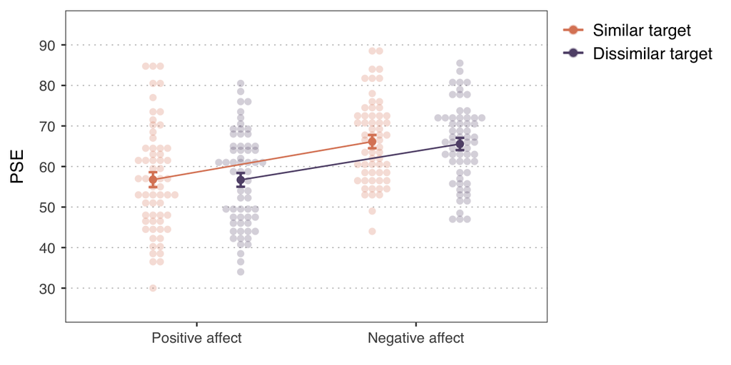

```r
# means & confidence intervals (within-subject, method from Morey 2008)
descr.pse <- summarySEwithin(data=d.pse, measurevar='pse',
                                    betweenvars=NULL, withinvars=c('affect', 'similarity'),
                                    idvar='id', na.rm=FALSE, conf.interval=0.95)

# figure
ggplot(descr.pse, aes(y=pse, x=affect, color=similarity, fill=similarity)) +

  # plot individual observations
  geom_dotplot(data=d.pse, aes(y=pse, x=affect, fill=similarity), binwidth=1.5, dotsize=1.2,
               binaxis='y', stackdir='centerwhole', alpha=.25, stroke=0, position=position_dodge(dodge_width)) +

  # plot means and CI
  geom_point(position=position_dodge(dodge_width), size=point_size) +
  geom_line(aes(group=similarity), position=position_dodge(dodge_width)) +
  geom_errorbar(aes(ymin=pse-ci, ymax=pse+ci), width=error_width, size=error_size, position=position_dodge(dodge_width)) +

  # format
  scale_y_continuous(name='PSE', breaks=seq(0, 100, by=10), limits=c(25, 95)) +
  scale_x_discrete(name='affect', labels=c(positive='Positive affect', negative='Negative affect')) +
  scale_color_manual(values=color_similarity, labels=labels_similarity) +
  scale_fill_manual(values=color_similarity, labels=labels_similarity) +
  my_theme + theme(axis.title.x=element_blank())
```

```r
# descriptive statistics
descr.pse <- d.pse %>%
  select(id, affect, similarity, pse) %>%
  dplyr::group_by(affect, similarity) %>%
  get_summary_stats(type='mean_sd') %>%
  select('Affect'=affect, 'Similarity'=similarity, 'N'=n, 'Mean'=mean, 'SD'=sd)

# main effect of affect
descr.pse.maineffect <- d.pse %>%
  select(id, affect, similarity, pse) %>%
  dplyr::group_by(id, affect) %>%
  dplyr::summarise(pse=mean(pse)) %>%
  dplyr::group_by(affect) %>%
  get_summary_stats(type='mean_sd') %>%
  add_column(similarity = 'similar + dissimilar') %>%
  select('Affect'=affect, 'Similarity'=similarity, 'N'=n, 'Mean'=mean, 'SD'=sd)

# merge both tables
rbind(descr.pse, descr.pse.maineffect) %>%
  kbl(digits=2, caption='PSE') %>%
  kable_styling(bootstrap_options=c('hover', 'condensed'), full_width=F, position='center') %>%
  row_spec(5:6, background='#f0f0f0')
```

PSE

| Affect | Similarity | N | Mean | SD |
| --- | --- | --- | --- | --- |
| positive | similar | 62 | 56.76 | 12.99 |
| positive | dissimilar | 62 | 56.70 | 11.49 |
| negative | similar | 62 | 66.14 | 9.93 |
| negative | dissimilar | 62 | 65.55 | 9.49 |
| positive | similar + dissimilar | 62 | 56.73 | 11.27 |
| negative | similar + dissimilar | 62 | 65.84 | 8.85 |

### ANOVA

To check whether the degree of egocentric biases in emotion judgments was modulated by the similarity with the target, a repeated-measures ANOVA was conducted on the PSEs, with `Affective State` (positive affect, negative affect) and `Similarity` (similar target, dissimilar target) as within-subject factors.

```r
# anova
m.pse <- aov_4(pse ~ affect*similarity + (affect*similarity|id), d.pse)
kbl(nice(m.pse, es='pes'), caption='ANOVA') %>%
  kable_styling(bootstrap_options=c('hover', 'condensed'), full_width=F, position='center')
```

ANOVA

| Effect | df | MSE | F | pes | p.value |
| --- | --- | --- | --- | --- | --- |
| affect | 1, 61 | 51.97 | 99.06 *** | .619 | <.001 |
| similarity | 1, 61 | 69.16 | 0.09 | .002 | .761 |
| affect:similarity | 1, 61 | 9.85 | 0.45 | .007 | .507 |

### Main contrast of interest

The [preregistered](https://osf.io/kjb84) interaction contrast aimed to directly compare the bias scores for similar vs. dissimilar targets. Individual bias scores were computed as the difference between the PSE estimated for each target in the negative affect condition compared to the positive affect condition. Positive bias scores are indicative of egocentricity, as they reflect a lower tendency to judge the facial expressions as happy after negative affect induction than after positive affect induction.

```r
# compute EEB scores by subtracting PSE_negative minus PSE_positive
d.eeb <- d.pse %>%
  select(id, affect, similarity, pse) %>%
  spread(affect, pse) %>%
  dplyr::group_by(id, similarity) %>%
  mutate(eeb=(negative-positive))
d.eeb <- as.data.frame(d.eeb)
```

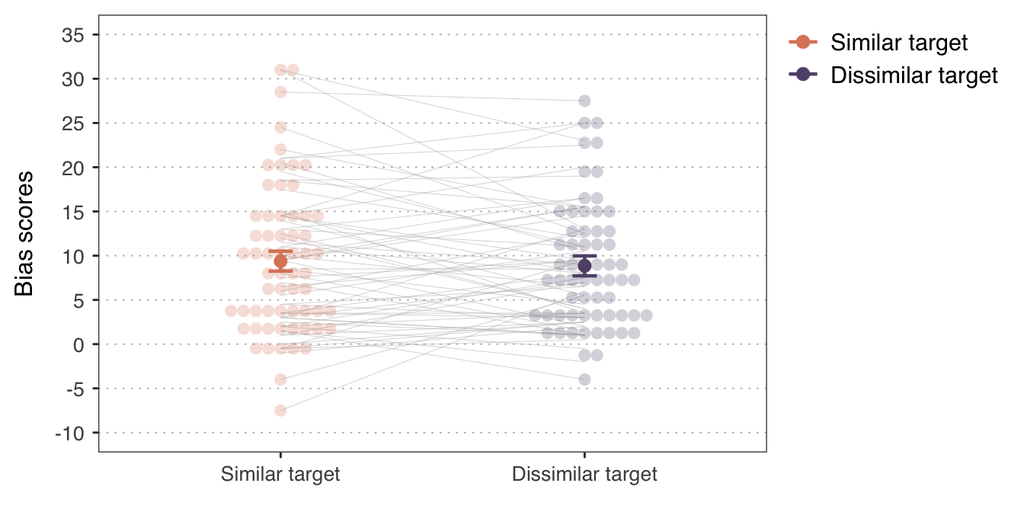

```r
# means & confidence intervals (within-subject, method from Morey 2008)
descr.eeb <- summarySEwithin(data=d.eeb, measurevar='eeb',
                                    betweenvars=NULL, withinvars=c('similarity'),
                                    idvar='id', na.rm=FALSE, conf.interval=0.95)

# figure
ggplot(descr.eeb, aes(y=eeb, x=similarity, color=similarity, fill=similarity)) +

  # plot individual observations
  geom_line(data=d.eeb, aes(y=eeb, x=similarity, group=id), size=0.1, color='grey') +
  geom_dotplot(data=d.eeb, aes(y=eeb, x=similarity), binwidth=2, dotsize=0.7,
               binaxis='y', stackdir='centerwhole', alpha=.25, stroke=0, position=position_dodge(dodge_width)) +

  # plot means and CI
  geom_point(position=position_dodge(dodge_width), size=point_size+0.5) +
  geom_line(aes(group=similarity), position=position_dodge(dodge_width)) +
  geom_errorbar(aes(ymin=eeb-ci, ymax=eeb+ci), width=error_width, size=error_size, position=position_dodge(dodge_width)) +

  # format
  scale_y_continuous(name='Bias scores', breaks=seq(-15, 45, by=5), limits=c(-10, 35)) +
  scale_x_discrete(name='Similarity', labels=c(similar='Similar target', dissimilar='Dissimilar target')) +
  scale_color_manual(values=color_similarity, labels=labels_similarity) +
  scale_fill_manual(values=color_similarity, labels=labels_similarity) +
  my_theme +  theme(axis.title.x=element_blank())
```

```r
# descriptive stats EEB scores
d.eeb %>%
  group_by(similarity) %>%
  get_summary_stats(eeb, type='mean_sd') %>%
  select('Similarity'=similarity, 'N'=n, 'Mean'=mean, 'SD'=sd) %>%
  kbl(digits=2, caption='Bias scores') %>%
  kable_styling(bootstrap_options=c('hover', 'condensed'), full_width=F, position='center')
```

Bias scores

| Similarity | N | Mean | SD |
| --- | --- | --- | --- |
| similar | 62 | 9.38 | 8.51 |
| dissimilar | 62 | 8.85 | 7.16 |

```r
# Preregistered comparison of interest (EEB-similar > EEB-dissimilar)
eeb.ttest <- d.eeb %>%
  pairwise_t_test(eeb~similarity, paired=TRUE, alternative='greater', conf.level=.95, detailed=TRUE) %>%
  inner_join(cohens_d(data=d.eeb, eeb~similarity, paired=TRUE)) %>%
  select('Condition 1'=group1, 'Condition 2'=group2, 'N'=n1,
         'Estimate'=estimate, 't'=statistic, 'DF'=df, 'p'=p,
         'CI Low'=conf.low, 'CI High'=conf.high, "Cohen's d"=effsize)

kbl(eeb.ttest, digits=2, caption='Paired-samples t-test (one-sided)') %>%
  kable_styling(bootstrap_options=c('hover', 'condensed'), full_width=F, position='center')
```

Paired-samples t-test (one-sided)

| Condition 1 | Condition 2 | N | Estimate | t | DF | p | CI Low | CI High | Cohen’s d |
| --- | --- | --- | --- | --- | --- | --- | --- | --- | --- |
| similar | dissimilar | 62 | 0.53 | 0.67 | 61 | 0.25 | -0.8 | Inf | 0.08 |

### Equivalence testing

Because null-hypothesis significance testing can only reject the presence of an effect, we cannot conclude that similarity does not influence the degree of egocentric biases based on the non-significant interaction. To test whether egocentric biases were statistically equivalent for similar and dissimilar targets, we applied equivalence testing on the critical interaction contrast using the Two One-Sided Tests procedure (Lakens, 2017). Equivalence bounds were determined based on the [preregistered](https://osf.io/kjb84) smallest effect size of interest used to decide the study sample size (Cohen’s *d* = 0.35).

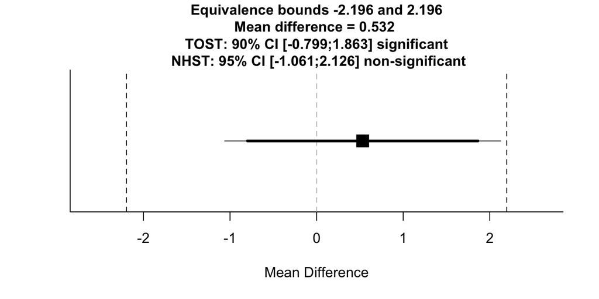

```
## TOST results:
## t-value lower bound: 3.42    p-value lower bound: 0.0006
## t-value upper bound: -2.09   p-value upper bound: 0.020
## degrees of freedom : 61
##
## Equivalence bounds (Cohen's dz):
## low eqbound: -0.35
## high eqbound: 0.35
##
## Equivalence bounds (raw scores):
## low eqbound: -2.1965
## high eqbound: 2.1965
##
## TOST confidence interval:
## lower bound 90% CI: -0.799
## upper bound 90% CI:  1.863
##
## NHST confidence interval:
## lower bound 95% CI: -1.061
## upper bound 95% CI:  2.126
##
## Equivalence Test Result:
## The equivalence test was significant, t(61) = -2.088, p = 0.0205, given equivalence bounds of -2.196 and 2.196 (on a raw scale) and an alpha of 0.05.
## Null Hypothesis Test Result:
## The null hypothesis test was non-significant, t(61) = 0.668, p = 0.507, given an alpha of 0.05.
## Based on the equivalence test and the null-hypothesis test combined, we can conclude that the observed effect is statistically not different from zero and statistically equivalent to zero.
```

```r
# Two one-sided tests (TOST) procedure for equivalence testing
d.eeb.similar <- d.eeb$eeb[d.eeb$similarity=='similar']
d.eeb.dissimilar <- d.eeb$eeb[d.eeb$similarity=='dissimilar']
sesoi <- 0.35

TOSTER::TOSTpaired(n=length(d.eeb.similar),
                   m1=mean(d.eeb.similar), m2=mean(d.eeb.dissimilar),
                   sd1=sd(d.eeb.similar), sd2=sd(d.eeb.dissimilar),
                   r12=cor(d.eeb.similar, d.eeb.dissimilar),
                   low_eqbound_dz=-sesoi, high_eqbound_dz=sesoi,
                   alpha=0.05, plot=TRUE, verbose=TRUE)
```

# Cognitive self-projection

A linear mixed-effect model (LMM) was used to examine the influence of perceived similarity on self-projection. Specifically, we tested whether the own attitudes with respect to a series of statements (`Self-ratings`) predicted the inferred attitudes of others (`Other-ratings`), and whether this relationship was dependent on the similarity with the target (`Similarity`).

The LMM used to test our hypothesis was as follows:

`Other-rating ~ Self-rating + Similarity + Self-rating * Similarity +` `(1 + Self-rating | Participant) +` `(1 + Similarity | Item) +` `(1 | Target identity)`

## Model specification

### Fixed effects

The `Other-ratings` were used as the dependent variable in the LMM. `Self-ratings`, `Similarity` and their interaction `Self-ratings*Similarity` were included as fixed effects. Effect coding was set for the categorical predictor (Similar vs. Dissimilar), and self-ratings were mean-centered.

- A significant main effect of `Self-ratings` would indicate that individuals use the own attitudes to predict the attitudes of other people (self-projection).
- A significant interaction `Self-rating*Similarity` would provide evidence that the degree of self-projection depends on the perceived similarity with the target.

### Random effects

The LMM included random intercepts for participants (`1|Participant`), items (`1|Item`) and target (`1|Target identity`). To determine the random slopes, iterative rounds of principal component analysis (PCA) were conducted to remove the random slopes from the maximal model that explained zero variance or which led to convergence issues. We followed the following steps:

1. Perform a PCA on the maximal LMM supported by the data and task design. If all principle components (PC) explain non-zero variance, use the maximal LMM as the final model. If the maximal model does not converge, proceed to step 2.
2. If one (or more) PC explain zero variance, fit the LMM without the correlation parameters. If this model converges, take this as the final model. If not, proceed to step 3.
3. Remove the predictor with the smallest variance of random slopes, and add the correlation parameters to this reduced model. Perform a PCA to check whether all PCs explain non-zero variance. If not, repeat steps 2 and 3 until finding the parsimonious LMM that converges.

#### M1.1: maximal

We started with the maximal LMM allowed by the data and task design:

`Other-rating ~ Self-rating + Similarity + Self-rating * Similarity +` `(1 + Self-rating * Similarity | Participant) +` `(1 + Self-rating * Similarity | Item) +` `(1 + Similarity | Target identity)`

The maximal LMM led to singular fit. In addition, several PCs explained 0 variance, which suggests that the random-effect structure was not optimal. We therefore looked for a more parsimonious version of the LMM (see M1.2).

```r
# NOTE: this is actually not the model that was included in the preregistration as the "maximal model". The preregistered model [Other-rating ~ Self*Similarity + (Self*Similarity|ID) + (Similarity|Item) + (Similarity|Target)] was actually not the maximal model allowed by the task design and data, as it was missing the by-item random slope for rating_self, as well as the interaction self*similarity.

# M1.1: maximal model
m11 <- lmer(rating_other ~ rating_self_cen*similarity + (1+rating_self_cen*similarity|id) + (1+rating_self_cen*similarity|item) + (1+similarity|identity), data=d.cet)
summary(rePCA(m11))
```

```
## $id
## Importance of components:
##                          [,1]   [,2]    [,3] [,4]
## Standard deviation     0.1984 0.1039 0.07354    0
## Proportion of Variance 0.7084 0.1943 0.09733    0
## Cumulative Proportion  0.7084 0.9027 1.00000    1
##
## $item
## Importance of components:
##                          [,1]   [,2]    [,3] [,4]
## Standard deviation     0.1970 0.1065 0.04617    0
## Proportion of Variance 0.7425 0.2168 0.04077    0
## Cumulative Proportion  0.7425 0.9592 1.00000    1
##
## $identity
## Importance of components:
##                          [,1]      [,2]
## Standard deviation     0.0233 1.914e-05
## Proportion of Variance 1.0000 0.000e+00
## Cumulative Proportion  1.0000 1.000e+00
```

```r
VarCorr(m11)
```

```
##  Groups   Name                        Std.Dev. Corr
##  id       (Intercept)                 0.202305
##           rating_self_cen             0.137980 -0.200
##           similarity1                 0.212244 -0.045 -0.196
##           rating_self_cen:similarity1 0.354379  0.638  0.046  0.666
##  item     (Intercept)                 0.394483
##           rating_self_cen             0.107061 -0.219
##           similarity1                 0.219613 -0.246 -0.337
##           rating_self_cen:similarity1 0.040687  0.823 -0.020  0.212
##  identity (Intercept)                 0.042986
##           similarity1                 0.020149 -1.000
##  Residual                             2.037098
```

#### M1.2: maximal’

This LMM was composed by the same random effects as the maximal model (M1.1), but without the correlation parameters:

`Other-rating ~ Self-rating + Similarity + Self-rating * Similarity +` `(1 + Self-rating * Similarity || Participant) +` `(1 + Self-rating * Similarity || Item) +` `(1 + Similarity || Target identity)`

As this LMM did not converge and several PCs explained 0 variance, we proceeded by reducing the random effects structure (see M2.1).

```r
# M1.2: "maximal" model without correlation parameters
m12 <- lmer(rating_other ~ rating_self_cen*similarity + (1+rating_self_cen*similarity||id) + (1+rating_self_cen*similarity||item) + (1+similarity||identity), data=d.cet)
summary(rePCA(m12))
```

```
## $id
## Importance of components:
##                          [,1]   [,2]    [,3]    [,4]      [,5]      [,6]
## Standard deviation     0.1367 0.1230 0.06722 0.04818 0.0003425 0.0001268
## Proportion of Variance 0.4597 0.3721 0.11116 0.05711 0.0000000 0.0000000
## Cumulative Proportion  0.4597 0.8317 0.94288 1.00000 1.0000000 1.0000000
##
## $item
## Importance of components:
##                          [,1]    [,2]    [,3]    [,4]      [,5]     [,6]
## Standard deviation     0.2545 0.07313 0.07155 0.06609 3.142e-05 1.06e-05
## Proportion of Variance 0.8136 0.06720 0.06432 0.05488 0.000e+00 0.00e+00
## Cumulative Proportion  0.8136 0.88080 0.94512 1.00000 1.000e+00 1.00e+00
##
## $identity
## Importance of components:
##                           [,1]     [,2] [,3]
## Standard deviation     0.03815 0.000101    0
## Proportion of Variance 0.99999 0.000010    0
## Cumulative Proportion  0.99999 1.000000    1
```

```r
VarCorr(m12)
```

```
##  Groups     Name                                 Std.Dev.   Corr
##  id         (Intercept)                          6.9920e-04
##  id.1       rating_self_cen                      9.8353e-02
##  id.2       similaritysimilar                    1.4973e-01
##             similaritydissimilar                 2.3544e-01 1.000
##  id.3       rating_self_cen:similaritysimilar    2.0808e-01
##             rating_self_cen:similaritydissimilar 1.9633e-01 -0.538
##  item       (Intercept)                          1.4606e-01
##  item.1     rating_self_cen                      6.4129e-05
##  item.2     similaritysimilar                    3.4780e-01
##             similaritydissimilar                 4.0875e-01 0.870
##  item.3     rating_self_cen:similaritysimilar    1.0267e-01
##             rating_self_cen:similaritydissimilar 1.0837e-01 1.000
##  identity   (Intercept)                          7.7871e-02
##  identity.1 similaritysimilar                    2.0585e-04
##             similaritydissimilar                 9.5830e-06 -1.000
##  Residual                                        2.0413e+00
```

#### M2.1: reduced

We first reduced the random effect structure of the maximal model by removing the higher-order random slopes (i.e. interactions), as well as the by-identity random slope of similarity, which explained little variance:

`Other-rating ~ Self-rating + Similarity + Self-rating * Similarity +` `(1 + Self-rating + Similarity | Participant) +` `(1 + Self-rating + Similarity | Item) +` `(1 | Target identity)`

As before, the last PCs of the by-id and by-participant random effects explained less than 1% of the variance, and the model lead to singular fits. We continued by assessing the same model, but removing the correlation parameters (see M2.2).

```r
# M2.1: model without (rating_self_cen:similarity|identity), (rating_self_cen:similarity|identity), (similarity|identity)
m21 <- lmer(rating_other ~ rating_self_cen*similarity + (1+rating_self_cen+similarity|id) + (1+rating_self_cen+similarity|item) + (1|identity), data=d.cet)
summary(rePCA(m21))
```

```
## $id
## Importance of components:
##                           [,1]    [,2]      [,3]
## Standard deviation     0.09952 0.06745 8.818e-06
## Proportion of Variance 0.68528 0.31472 0.000e+00
## Cumulative Proportion  0.68528 1.00000 1.000e+00
##
## $item
## Importance of components:
##                          [,1]    [,2]    [,3]
## Standard deviation     0.1969 0.09293 0.03524
## Proportion of Variance 0.7970 0.17748 0.02552
## Cumulative Proportion  0.7970 0.97448 1.00000
##
## $identity
## Importance of components:
##                           [,1]
## Standard deviation     0.04086
## Proportion of Variance 1.00000
## Cumulative Proportion  1.00000
```

```r
VarCorr(m21)
```

```
##  Groups   Name            Std.Dev. Corr
##  id       (Intercept)     0.182967
##           rating_self_cen 0.136823 -0.242
##           similarity1     0.104392 -0.892 -0.223
##  item     (Intercept)     0.392179
##           rating_self_cen 0.104108 -0.254
##           similarity1     0.218586 -0.501 -0.389
##  identity (Intercept)     0.085369
##  Residual                 2.089356
```

#### M2.2: reduced’

The model M2.2 without the correlation parameters was as follows:

`Other-rating ~ Self-rating + Similarity + Self-rating * Similarity +` `(1 + Self-rating + Similarity || Participant) +` `(1 + Self-rating + Similarity || Item) +` `(1 || Target identity)`

This LMM did not converge either. Several PCs, as well as the by-id and by-participant random effects explained near-to-zero variance. Therefore, we reduced the random effects structure once more by removing the random slopes with smallest variance in M3.

```r
# M2.2: model without (rating_self_cen:similarity|identity), (rating_self_cen:similarity|identity), (similarity|identity), and without correlation parameters
m22 <- lmer(rating_other ~ rating_self_cen*similarity + (1+rating_self_cen+similarity||id) + (1+rating_self_cen+similarity||item) + (1|identity), data=d.cet)
summary(rePCA(m22))
```

```
## $id
## Importance of components:
##                          [,1]    [,2]      [,3]      [,4]
## Standard deviation     0.1288 0.06551 5.698e-05 1.426e-05
## Proportion of Variance 0.7944 0.20562 0.000e+00 0.000e+00
## Cumulative Proportion  0.7944 1.00000 1.000e+00 1.000e+00
##
## $item
## Importance of components:
##                          [,1]    [,2]    [,3]      [,4]
## Standard deviation     0.2681 0.06345 0.04991 0.0001937
## Proportion of Variance 0.9169 0.05135 0.03177 0.0000000
## Cumulative Proportion  0.9169 0.96823 1.00000 1.0000000
##
## $identity
## Importance of components:
##                           [,1]
## Standard deviation     0.04188
## Proportion of Variance 1.00000
## Cumulative Proportion  1.00000
```

```r
VarCorr(m22)
```

```
##  Groups   Name                 Std.Dev.   Corr
##  id       (Intercept)          0.00011906
##  id.1     rating_self_cen      0.13687748
##  id.2     similaritysimilar    0.13623446
##           similaritydissimilar 0.23199565 1.000
##  item     (Intercept)          0.00040476
##  item.1   rating_self_cen      0.10427421
##  item.2   similaritysimilar    0.35057027
##           similaritydissimilar 0.45657561 0.886
##  identity (Intercept)          0.08750702
##  Residual                      2.08933840
```

#### M3: final

We removed the random slopes with smallest variance from the last model tested ( `Similarity | Participant`, `Self-rating | Item`). The resulting LMM was as follows:

`Other-rating ~ Self-rating + Similarity + Self-rating * Similarity +` `(1 + Self-rating | Participant) +` `(1 + Similarity | Item) +` `(1 | Target identity)`

This time the model converged and all PCs explained non-zero variance (Yay!). We used this model to test the hypothesis.

```r
# M3: model without (similarity|id), (rating_self_cen|id)
m31 <- lmer(rating_other ~ rating_self_cen*similarity + (1+rating_self_cen|id) + (1+similarity|item) + (1|identity), data=d.cet)
summary(rePCA(m31))
```

```
## $id
## Importance of components:
##                           [,1]    [,2]
## Standard deviation     0.08421 0.06175
## Proportion of Variance 0.65034 0.34966
## Cumulative Proportion  0.65034 1.00000
##
## $item
## Importance of components:
##                          [,1]    [,2]
## Standard deviation     0.2126 0.08735
## Proportion of Variance 0.8555 0.14446
## Cumulative Proportion  0.8555 1.00000
##
## $identity
## Importance of components:
##                          [,1]
## Standard deviation     0.0412
## Proportion of Variance 1.0000
## Cumulative Proportion  1.0000
```

```r
VarCorr(m31)
```

```
##  Groups   Name            Std.Dev. Corr
##  id       (Intercept)     0.171735
##           rating_self_cen 0.136797 -0.206
##  item     (Intercept)     0.432981
##           similarity1     0.214525 -0.468
##  identity (Intercept)     0.086621
##  Residual                 2.102637
```

#### Model comparison

```r
# null model
m01 <- lmer(rating_other ~ rating_self_cen*similarity + (1|id) + (1|item) + (1|identity), data=d.cet)

# NOTE: use "refit=FALSE" when comparing models that only differ in the random structure, as it is better to compare models with REML. If anova() is performed to compare differences between models differing in fixed effects, then better refit the models with ML.
anova(m01, m11, m21, m31, refit=FALSE)
```

```
## Data: d.cet
## Models:
## m01: rating_other ~ rating_self_cen * similarity + (1 | id) + (1 |
## m01:     item) + (1 | identity)
## m31: rating_other ~ rating_self_cen * similarity + (1 + rating_self_cen |
## m31:     id) + (1 + similarity | item) + (1 | identity)
## m21: rating_other ~ rating_self_cen * similarity + (1 + rating_self_cen +
## m21:     similarity | id) + (1 + rating_self_cen + similarity | item) +
## m21:     (1 | identity)
## m11: rating_other ~ rating_self_cen * similarity + (1 + rating_self_cen *
## m11:     similarity | id) + (1 + rating_self_cen * similarity | item) +
## m11:     (1 + similarity | identity)
##     npar   AIC   BIC  logLik deviance  Chisq Df Pr(>Chisq)
## m01    8 16306 16356 -8144.9    16290
## m31   12 16266 16341 -8121.0    16242 47.749  4  1.064e-09 ***
## m21   18 16256 16368 -8110.1    16220 21.765  6   0.001335 **
## m11   28 16178 16352 -8061.1    16122 98.101 10  < 2.2e-16 ***
## ---
## Signif. codes:  0 '***' 0.001 '**' 0.01 '*' 0.05 '.' 0.1 ' ' 1
```

### Model diagnostics

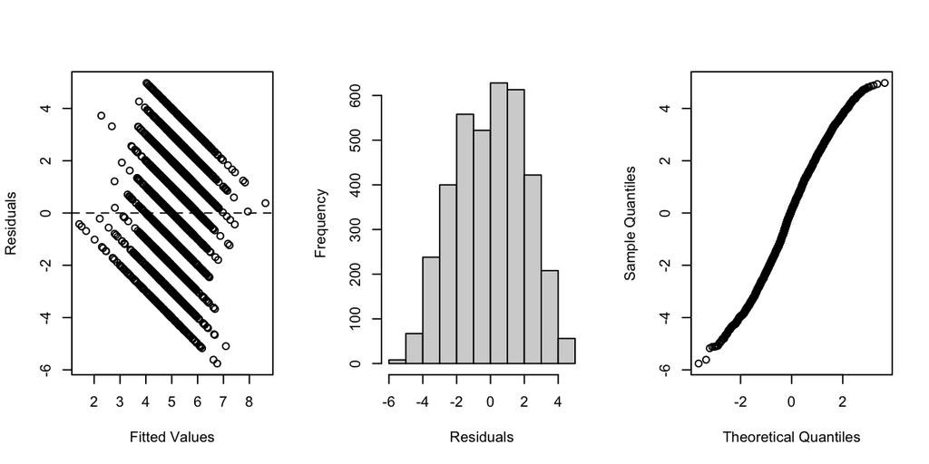

```r
# residual plots to check linearity and homocedasticity
layout(matrix(c(1,2,3), 1, 3))
plot(fitted(m31), residuals(m31), main='', xlab='Fitted Values', ylab='Residuals', abline(h=0, lty=2))
hist(residuals(m31), main='', xlab='Residuals')
qqnorm(residuals(m31), main='')
```

```r
layout(1)
```

## LMM results

```r
# run final model
m.cet <- lmer(rating_other ~ rating_self_cen*similarity + (1+rating_self_cen|id) + (1+similarity|item) + (1|identity), data=d.cet)
summary(m.cet, corr=F)
```

[output not shown]

```r
# simple slopes
m.cet.slopes <- interactions::sim_slopes(m.cet, pred=rating_self_cen, modx=similarity)
m.cet.slopes
```

[output not shown]

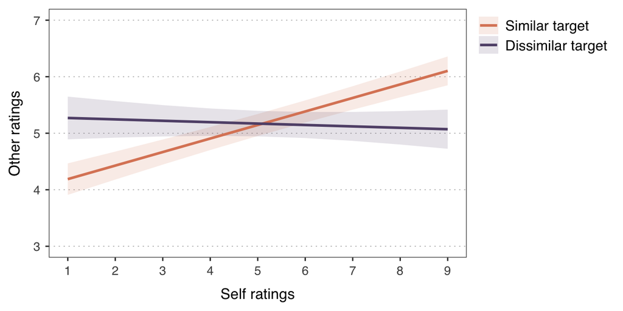

```r
# predicted effects
pred.cet <- get_model_data(m.cet, type='pred', terms=c('rating_self_cen', 'similarity'))
names(pred.cet)[names(pred.cet)=='x'] <- 'rating_self'
names(pred.cet)[names(pred.cet)=='group_col'] <- 'similarity'

# back-transform mean-centered values for plotting
pred.cet$rating_self <- pred.cet$rating_self + attr(d.cet$rating_self_cen, 'scaled:center')

# plot predicted effects
fig.cet <- ggplot(pred.cet, aes(y=predicted, x=rating_self, group=similarity)) +

  # predicted fixed effect of mood
  geom_ribbon(aes(ymin=conf.low, ymax=conf.high, fill=similarity), alpha=.15, color='transparent') +
  geom_line(aes(color=similarity), size=line_size) +

  # format
  scale_y_continuous(name='Other ratings', breaks=seq(1,9,by=1), limits=c(3,7)) +
  scale_x_continuous(name='Self ratings', breaks=seq(1,9,by=1), limits=c(1,9)) +
  scale_color_manual(values=color_similarity, name='Target similarity', labels=labels_similarity) +
  scale_fill_manual(values=color_similarity, name='Target similarity', labels=labels_similarity) +
  my_theme

fig.cet
```